# BH Code Challenge

Allan Trapp II

7/27/2020

## Executive summary:

1. From which region are we most likely to find the highest quality wines?

If one were to randomly pick wines and define a ‘high quality’ wine of having at least a quality score of 6, then the answer is region C as it has the highest percent of bottles, 14.62%. Region C has the highest average of quality scores, 6.38, and is the second largest producer of wines (1092) compared to F (1332), the largest producer. I hypothesize that C is more of the mind, ‘quality over quantity,’ as 86.9% of its wines have scores > 5. Only 67.0% of region F’s wines meet this criteria, even though it is the largest producing region.

2. Please select 10 wines for the party. What are they, and why did you select them?

My objective was to ensure that diverse, high quality, red and white wines were available. As such, I first subset the original wine dataframe into red and white lists where wine quality was either 8 or 9. To drive diversity, I performed agglomerative hierarchical clustering with Ward’s method on each list. Groupings were solely based on the continuous attributes of fixed.acidity, volatile.acidity, citric.acid, residual.sugar, chlorides, free.sulfur.dioxide, total.sulfur.dioxide, density, pH, sulphates, and alcohol. This is the list of wines with ID:

Color: ID-Region

White: 2210-C  
White: 3315-F  
White: 2507-C  
White: 3397-B  
White: 5932-G  
White: 4630-B  
White: 4348-H Red: 1203-C  
Red: 496-C  
Red: 1270-H

This recommendation list contains more whites as 75% of the big list is white.

3. Which of the characteristics most influence wine quality?

Alcohol is the most influential characteristic on wine quality. Of all of the characteristics, it has the strongest Pearson correlation of 0.44. More importantly, in a model with good predictive accuracy of wine quality scores (f1=0.67, recall=0.688, and precision = 0.683), it is the most important variable as determined by the decreases in Gini and accuracy scores.

4. Despite his gruff exterior, it turns out that Matt Crisp, the CEO of Benson Hill, has a sweet tooth and that he only likes the sweetest of wines. He also has knowledge of flavor and thus dislikes the “barnyard” features of wines with high free sulfur dioxide. Taking into account Matt’s preferences, and all the other features of quality, which wine would you select for him? Why?

I would recommend that Matt have a glass of the 4630. It has a quality score of 8 and of all high quality wines (scores of 8 or 9), this wine has the highest residual sugar, 14.8, and a low free sulfur dioxide of 22.

## Data

```r
# Loading packages that will be leveraged in this analysis
library(googlesheets4)
library(dplyr)
```

```r
library(ggplot2)
library(psych)
library(cluster)
library(purrr)
library(factoextra)
library(catboost)
library(randomForest)
library(caTools)
library(caret)
# Following line used to install catboost from github
# devtools::install_github('catboost/catboost', subdir = 'catboost/R-package')

# Sourcing supporting general R functions that I use for most projects.

source('utility.R')
```

### Loading data

Reading data into R from my personal google drive. I am treating this like a ‘central’ data storage place to enable reproducibility of work. This is googlesheet version of the WineData.csv that was shared through email.

```r
df <- googlesheets4::read_sheet('179prhCDCppqPjAlnA26FEROVqIHUR8OWwyb2QWbOfd8',
                        sheet = 'WineData')
```

[output not shown]

```
## The googlesheets4 package is using a cached token for allantrapp2@gmail.com.
```

```
## Auto-refreshing stale OAuth token.
```

```
## Reading from "WineData"
```

```
## Range "'WineData'"
```

```
## * `` -> ...1
```

### Exploration of data

Objective of this exercise is to create wine recommendations. In the data set, ID is assumed to be the wine identifier, and `...1` will be removed. The following code was my verification that the two columns are identical.

```r
head(df)
```

```
## # A tibble: 6 x 16
##    ...1    ID color region fixed.acidity volatile.acidity citric.acid
##   <dbl> <dbl> <chr> <chr>          <dbl>            <dbl>       <dbl>
## 1     1     1 red   I                7.4             0.7         0
## 2     2     2 red   E                7.8             0.88        0
## 3     3     3 red   A                7.8             0.76        0.04
## 4     4     4 red   E               11.2             0.28        0.56
## 5     5     5 red   I                7.4             0.7         0
## 6     6     6 red   I                7.4             0.66        0
## # … with 9 more variables: residual.sugar <dbl>, chlorides <dbl>,
## #   free.sulfur.dioxide <dbl>, total.sulfur.dioxide <dbl>, density <dbl>,
## #   pH <dbl>, sulphates <dbl>, alcohol <dbl>, quality <dbl>
```

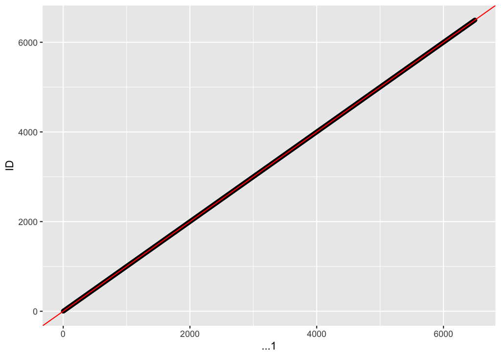

```r
ggplot(data = df, aes(x = ...1, y = ID)) + geom_point() +
  geom_abline(intercept = 0, slope =1, col='red')
```

```r
print(paste0('RMSE between ...1 and ID is ', f_rmse(df$...1, df$ID))) # Function may be found in 'utility.R' script
```

```
## [1] "RMSE between ...1 and ID is 0"
```

```r
sdf <- dplyr::select(df, -c('...1', 'ID'))
head(sdf)
```

```
## # A tibble: 6 x 14
##   color region fixed.acidity volatile.acidity citric.acid residual.sugar
##   <chr> <chr>          <dbl>            <dbl>       <dbl>          <dbl>
## 1 red   I                7.4             0.7         0               1.9
## 2 red   E                7.8             0.88        0               2.6
## 3 red   A                7.8             0.76        0.04            2.3
## 4 red   E               11.2             0.28        0.56            1.9
## 5 red   I                7.4             0.7         0               1.9
## 6 red   I                7.4             0.66        0               1.8
## # … with 8 more variables: chlorides <dbl>, free.sulfur.dioxide <dbl>,
## #   total.sulfur.dioxide <dbl>, density <dbl>, pH <dbl>, sulphates <dbl>,
## #   alcohol <dbl>, quality <dbl>
```

Next step of analysis is understanding the data completeness. First, I determine if there are duplicate rows in the data set.

```r
df_summary <- f_eda(sdf)
print(paste0("Number of unique wines = ", length(unique(df$ID)),
      ' and number of data rows = ',nrow(df)))
```

```
## [1] "Number of unique wines = 6497 and number of data rows = 6497"
```

```r
print(paste0("Number of duplicate feature rows = ", nrow(df_summary$duplicate_rows)))
```

```
## [1] "Number of duplicate feature rows = 1177"
```

```r
print(paste("There are", df_summary$duplicate_rows %>% n_distinct(),"vectors of traits associated with 2 or more wines."))
```

```
## [1] "There are 992 vectors of traits associated with 2 or more wines."
```

There are 6,497 unique ID’s and rows in the complete data set –> records have not been duplicated. However, there are wines that have the exact same quantitative/qualitative characteristics. This raises the question: Is it possible for two wines to have the exact same characteristics?

Next, I check completeness of records. If data are sparse, this will inform whether or not certain variables will go into modeling and if imputation should be considered. Additionally, it creates talking points with the data owners–sometimes they forget to enter data.

```r
df_summary$missing_counts
```

```
##   color region fixed.acidity volatile.acidity citric.acid residual.sugar
## 1     0      0             0                0           0              0
##   chlorides free.sulfur.dioxide total.sulfur.dioxide density pH sulphates
## 1         0                   0                    0       0  0         0
##   alcohol quality
## 1       0       0
```

Data are complete! No need for imputation.

Third step is to investigate any correlations and distributions of variables in the data. It appears that there are two categorical variables/factors of color and region. Region F has the most wines, and there are more white than red wines in this study.

```r
df_summary$summaries_fact_cols
```

```
## $color
##
##   red white
##  1599  4898
##
## $region
##
##    A    B    C    D    E    F    G    H    I
##  882  998 1092  334  785 1332  358  369  347
```

```r
with(data=df, table(region, color))
```

```
##       color
## region  red white
##      A  206   676
##      B  195   803
##      C  333   759
##      D   82   252
##      E  346   439
##      F   95  1237
##      G  144   214
##      H   40   329
##      I  158   189
```

It also looks like there are 12 quantitative variables. Arguably, quality is an ordinal, categorical variable as it is a human assigned value. Note that the quality scores range between 3 and 9.

```r
df_summary$summaries_num_cols
```

```
##         fixed.acidity volatile.acidity citric.acid residual.sugar  chlorides
## Min.         3.800000         0.080000   0.0000000       0.600000 0.00900000
## 1st Qu.      6.400000         0.230000   0.2500000       1.800000 0.03800000
## Median       7.000000         0.290000   0.3100000       3.000000 0.04700000
## Mean         7.215307         0.339666   0.3186332       5.443235 0.05603386
## 3rd Qu.      7.700000         0.400000   0.3900000       8.100000 0.06500000
## Max.        15.900000         1.580000   1.6600000      65.800000 0.61100000
##         free.sulfur.dioxide total.sulfur.dioxide   density       pH sulphates
## Min.                1.00000               6.0000 0.9871100 2.720000 0.2200000
## 1st Qu.            17.00000              77.0000 0.9923400 3.110000 0.4300000
## Median             29.00000             118.0000 0.9948900 3.210000 0.5100000
## Mean               30.52532             115.7446 0.9946966 3.218501 0.5312683
## 3rd Qu.            41.00000             156.0000 0.9969900 3.320000 0.6000000
## Max.              289.00000             440.0000 1.0389800 4.010000 2.0000000
##         alcohol  quality
## Min.     8.0000 3.000000
## 1st Qu.  9.5000 5.000000
## Median  10.3000 6.000000
## Mean    10.4918 5.818378
## 3rd Qu. 11.3000 6.000000
## Max.    14.9000 9.000000
```

```r
colnames_num <- names(df_summary$summaries_num_cols)
print(paste0('Number of quantitative columns = ',length(colnames_num)))
```

```
## [1] "Number of quantitative columns = 12"
```

```r
cat('quantitative variables are:', colnames_num)
```

```
## quantitative variables are: fixed.acidity volatile.acidity citric.acid residual.sugar chlorides free.sulfur.dioxide total.sulfur.dioxide density pH sulphates alcohol quality
```

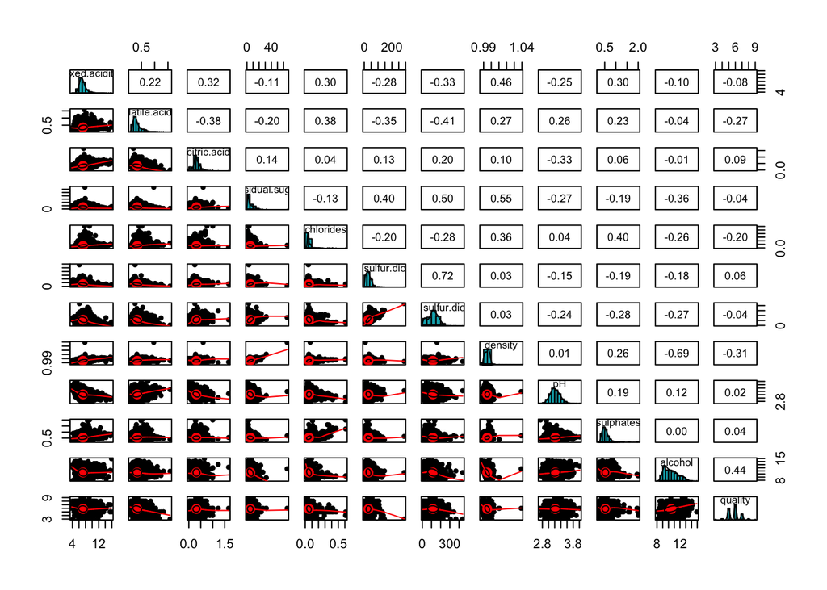

```r
psych::pairs.panels(dplyr::select(df,-c('color','region','ID','...1')),
                    method = "pearson", # correlation method
                    hist.col = "#00AFBB",
                    density = TRUE,  # show density plots
                    ellipses = TRUE # show correlation ellipses
)
```

For linear correlations (Pearson) to quality, alcohol content correlated the strongest (0.44) and density was second strongest (-0.31). Residual sugars and sulphates appear to be right-skewed distributions. Also, there’s a diversity of ranges for each variable. total.sulfur.dioxide ranges between 0 and 440 whereas citric.acid is between 0 and 1.66. Standardization will be considered for any clustering techniques.

#### Response to question 1:

```r
# Investigating quality scores

df %>% dplyr::group_by(region) %>%
  dplyr::summarise(ave_score = mean(quality, na.rm=TRUE),
                   med_score = median(quality, na.rm=TRUE),
                   q1 = quantile(quality, .25, na.rm=TRUE),
                   q3 = quantile(quality, .75, na.rm=TRUE),
                   iqr = q3-q1,
                   stdev = sd(quality,na.rm=TRUE),
                   n = length(quality)
                   )
```

```
## # A tibble: 9 x 8
##   region ave_score med_score    q1    q3   iqr stdev     n
##   <chr>      <dbl>     <dbl> <dbl> <dbl> <dbl> <dbl> <int>
## 1 A           5.34         5     5     6     1 0.588   882
## 2 B           5.84         6     5     6     1 0.801   998
## 3 C           6.38         6     6     7     1 0.869  1092
## 4 D           5.39         5     5     6     1 0.665   334
## 5 E           5.67         6     5     6     1 0.860   785
## 6 F           5.88         6     5     6     1 0.873  1332
## 7 G           5.97         6     5     7     2 0.965   358
## 8 H           5.92         6     5     6     1 0.810   369
## 9 I           5.47         5     5     6     1 0.734   347
```

```r
table(df$quality)
```

```
##
##    3    4    5    6    7    8    9
##   30  216 2138 2836 1079  193    5
```

Looking at regions where wine is produced, region C has the highest average quality rating of 6.38.

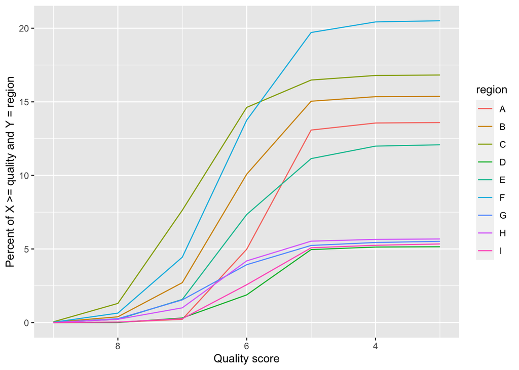

```r
pmf_region_quality <- data.frame(round(with(data=df, table(region, quality))/nrow(df),4))
pmf_region_quality <- pmf_region_quality %>%
  dplyr::arrange(region,desc(quality)) %>%
  dplyr::group_by(region) %>%
  dplyr::mutate(cum_prob=cumsum(Freq)*100)

ggplot(data=pmf_region_quality, aes(x=as.numeric(quality)+2, y=cum_prob, color=region)) +
  geom_line() +
  scale_x_reverse() +
  ylab('Percent of X >= quality and Y = region') +
  xlab('Quality score')
```

```r
pmf_region_quality %>% dplyr::filter(quality==6)
```

```
## # A tibble: 9 x 4
## # Groups:   region [9]
##   region quality   Freq cum_prob
##   <fct>  <fct>    <dbl>    <dbl>
## 1 A      6       0.0476     4.98
## 2 B      6       0.0737    10.1
## 3 C      6       0.0699    14.6
## 4 D      6       0.0157     1.88
## 5 E      6       0.0577     7.34
## 6 F      6       0.0931    13.8
## 7 G      6       0.0239     3.93
## 8 H      6       0.0319     4.19
## 9 I      6       0.0231     2.57
```

Looking at the plot above, there is a stronger likelihood that good quality wine comes from region C as the olive color line is above all others for high values of quality. To interpret the graphic, for the quality value of 6 in region C (olive line), 14.62 means that 14.62% of all wines had a quality of 6 or higher and originated from region C. For quality scores of 6, 7, 8, and 9, region C always has the highest percent of wines. An interesting point, region C does not produce the most wine, so it is not just volume driving the high joint probabilities. In fact, 87% of region C’s wines have quality scores larger than 5 whereas region F has only 67%. See code below for these conditional probability calculations.

```r
# Conditional probability calculations
df_cond <- df %>%
  dplyr::group_by(region, quality) %>%
  dplyr::summarize(counts = length(quality)) %>%
  dplyr::group_by(region) %>%
  dplyr::mutate(reg_total = sum(counts)) %>%
  dplyr::ungroup(region) %>%
  dplyr::mutate(p = counts/reg_total*100)
df_cond %>%
  dplyr::filter(quality > 5) %>%
  dplyr::group_by(region) %>%
  dplyr::summarize(p_cond = sum(p))
```

```
## # A tibble: 9 x 2
##   region p_cond
##   <chr>   <dbl>
## 1 A        36.6
## 2 B        65.6
## 3 C        86.9
## 4 D        36.5
## 5 E        60.8
## 6 F        67.0
## 7 G        71.2
## 8 H        73.7
## 9 I        48.1
```

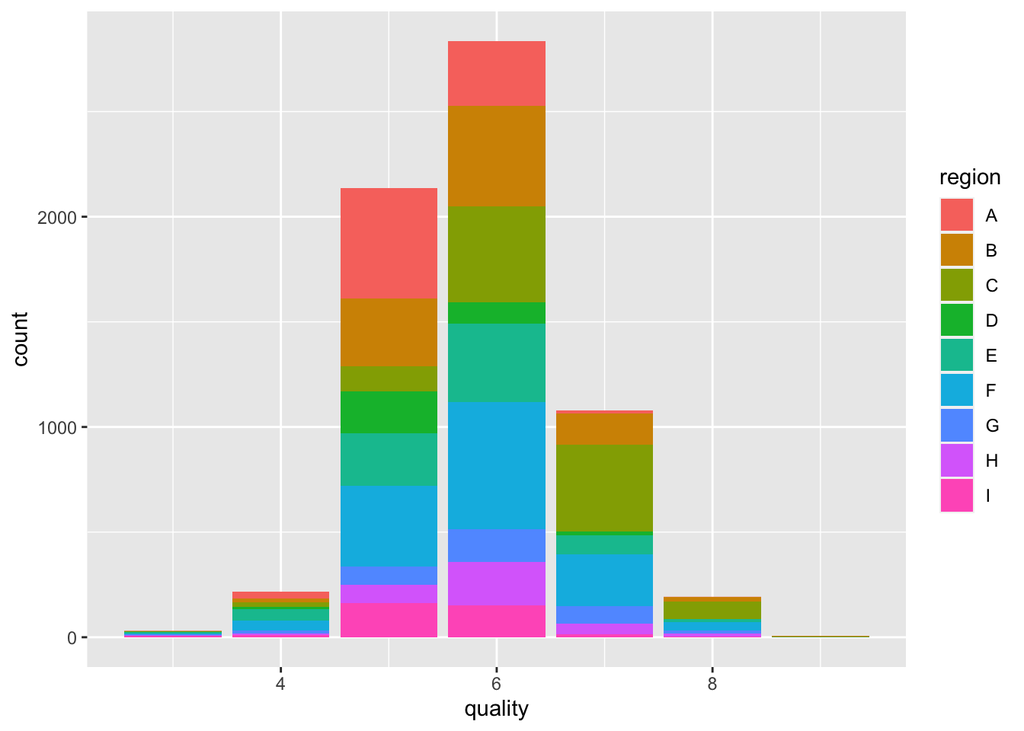

```r
ggplot(data=df, aes(x=quality)) + geom_bar(position='stack',aes(fill=region))
```

## Party wine selection: Clustering of wines, response to question 2

```r
# Only selecting wines with a quality score of 8 or higher
party_wines <- df %>% dplyr::filter(quality >=8)

cluster_cols <- setdiff(colnames_num, 'quality')

# Normalizing quantitative variables
scale2 <- function(x, na.rm = TRUE) (x - mean(x, na.rm = na.rm)) / sd(x, na.rm)
party_wines <- party_wines %>%
  dplyr::mutate_at(all_of(cluster_cols), scale2)

# Creating two separate wine lists for whites and reds
party_wines_red <- party_wines %>% dplyr::filter(color=='red')
party_wines_white <- party_wines %>% dplyr::filter(color=='white')

# Only 18 red wines have quality >=8
dim(party_wines_red)
```

```
## [1] 18 16
```

```r
# Only 180 white wines have quality >=8
dim(party_wines_white)
```

```
## [1] 180  16
```

```r
# Using Agnes coefficient to determine good clustering method
m <- c('average', 'single', 'complete', 'ward')
names(m) <- c('average', 'single', 'complete', 'ward')

# Agnes clustering function using red list
ac <- function(x){
  cluster::agnes(party_wines_red[,cluster_cols], method=x)$ac
}

# Agnes clustering function using white list
ac1 <- function(x){
  cluster::agnes(party_wines_white[,cluster_cols], method=x)$ac
}
purrr::map_dbl(m, ac)
```

```
##   average    single  complete      ward
## 0.6209827 0.3855310 0.7795045 0.8291297
```

```r
purrr::map_dbl(m, ac1)
```

```
##   average    single  complete      ward
## 0.8323981 0.8136266 0.8855133 0.9648037
```

```r
# Looks like Ward is best clustering algorithm for both list based on the Agnes coefficient.
```

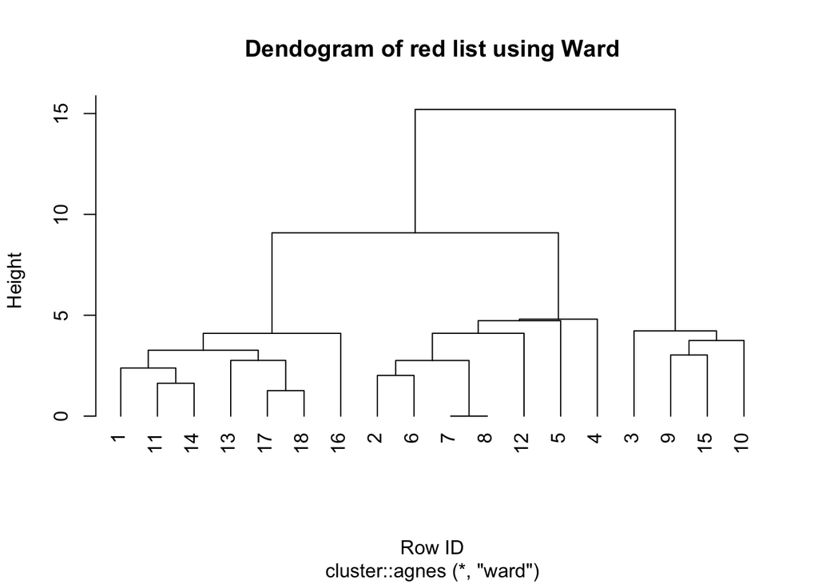

```r
hc_red <- cluster::agnes(party_wines_red[,cluster_cols], method = 'ward')
hc_white <- cluster::agnes(party_wines_white[,cluster_cols], method = 'ward')

# Plotting the tree diagrams
pltree(hc_red, hang=-1, main='Dendogram of red list using Ward',xlab='Row ID')
```

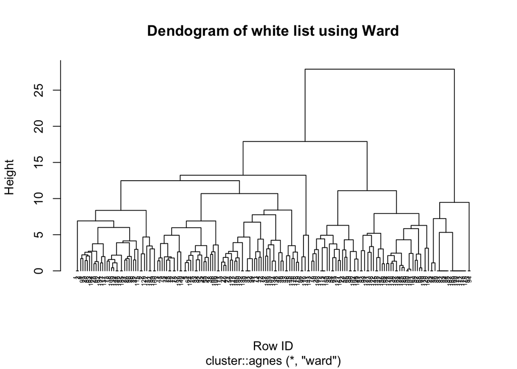

```r
pltree(hc_white, cex=.5, hang=-1, main='Dendogram of white list using Ward',xlab='Row ID')
```

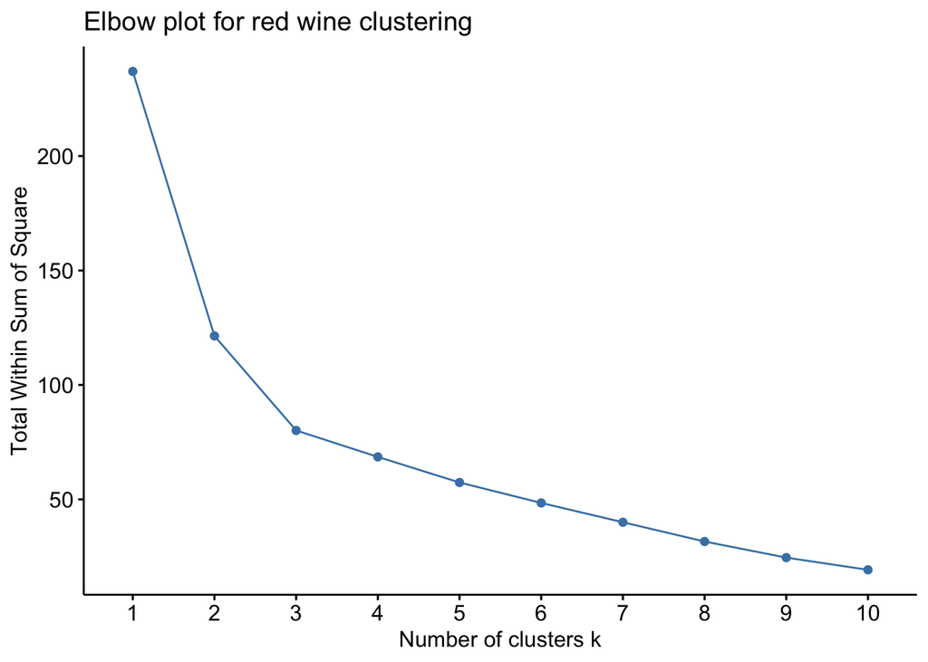

```r
# Number of clusters selected based on the dendogram
party_wines_red <- party_wines_red %>% dplyr::mutate(cluster = cutree(as.hclust(hc_red), k=3))
party_wines_white <- party_wines_white %>% dplyr::mutate(cluster = cutree(as.hclust(hc_white), k=7))

# Elbow plot to determine optimal number of clusters in the Red list
fviz_nbclust(party_wines_red[,cluster_cols], FUN = hcut, method = "wss") +
  ggtitle("Elbow plot for red wine clustering")
```

For the red list of wines with quality score of 8 or higher, elbow method shows that 3 clusters seems reasonable. As such, I will restrict the white list to 7 clusters to get 10 distinct groups of high quality red and white wines from which we will select diverse wines.

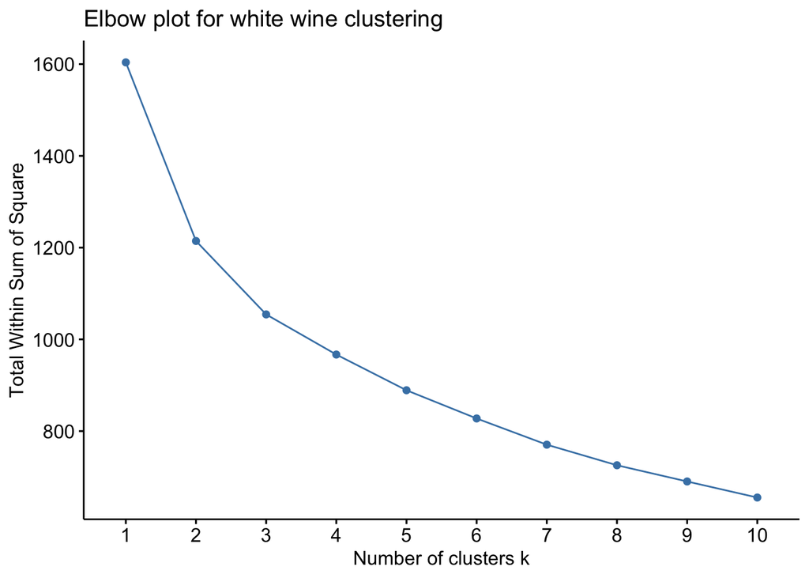

```r
# Elbow plot to determine optimal number of clusters in the White list
fviz_nbclust(party_wines_white[,cluster_cols], FUN = hcut, method = "wss") +
  ggtitle ("Elbow plot for white wine clustering")
```

```r
with(data=party_wines_red, table(region, cluster))
```

```
##       cluster
## region 1 2 3
##      C 5 4 0
##      E 1 1 1
##      G 1 2 0
##      H 0 0 3
```

```r
with(data=party_wines_white, table(region, cluster))
```

```
##       cluster
## region  1  2  3  4  5  6  7
##      A  0  0  0  1  0  0  0
##      B  3  2  0 16  0  4  0
##      C 22  1 25  4  0 23  0
##      E  6  0  3  0  0  2  0
##      F  6 24  8  0  0  3  0
##      G  0  0  0  0 14  0  0
##      H  0  2  0  1  3  0  5
##      I  0  0  0  0  2  0  0
```

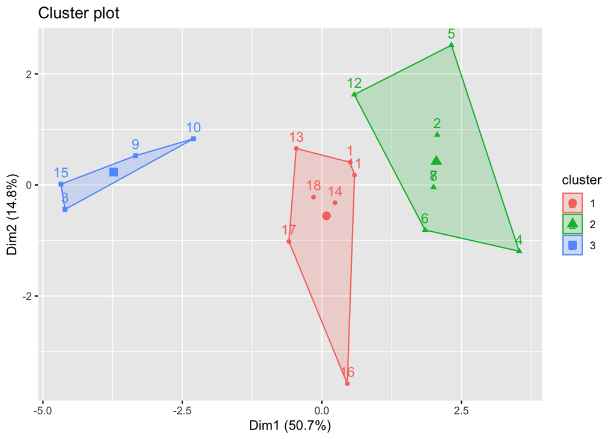

```r
# Visualizing the clusters using first two principle components as x and y axes
factoextra::fviz_cluster(list(data = party_wines_red[,cluster_cols], cluster=party_wines_red$cluster))
```

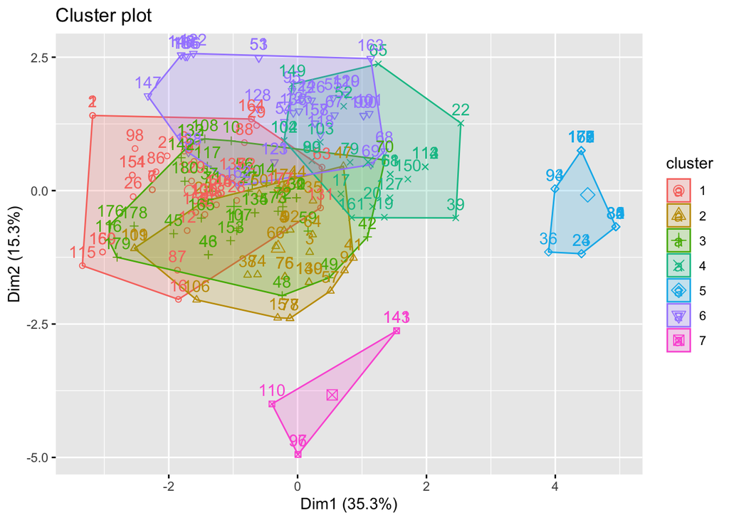

```r
factoextra::fviz_cluster(list(data = party_wines_white[,cluster_cols], cluster=party_wines_white$cluster))
```

```r
# Calculating centroids of each cluster
centroids_red <- party_wines_red %>%
  dplyr::select(c(cluster_cols, 'cluster', 'ID')) %>%
  dplyr::group_by(cluster) %>%
  summarise_at(vars(-ID), mean, na.rm=TRUE)
```

```
## Note: Using an external vector in selections is ambiguous.
## ℹ Use `all_of(cluster_cols)` instead of `cluster_cols` to silence this message.
## ℹ See <https://tidyselect.r-lib.org/reference/faq-external-vector.html>.
```

```r
centroids_white <- party_wines_white %>%
  dplyr::select(c(cluster_cols, 'cluster', 'ID')) %>%
  dplyr::group_by(cluster) %>%
  summarise_at(vars(-ID), mean, na.rm=TRUE)

# Finding the bottle of wine closest to the centoid
r_dist <- as.matrix(stats::dist(rbind(dplyr::select(centroids_red,-cluster),
                                      party_wines_red[,cluster_cols]),
                                method='euclidean'))[-c(1:3),1:3]
red_pos <- apply(r_dist,2,which.min)

w_dist <- as.matrix(stats::dist(rbind(dplyr::select(centroids_white, -cluster),
                                      party_wines_white[,cluster_cols]),
                                method='euclidean'))[-c(1:7),1:7]
white_pos <- apply(w_dist,2,which.min)

# This is the wine list!
party_wines_red[red_pos,c("ID", "cluster","region")]
```

```
## # A tibble: 3 x 3
##      ID cluster region
##   <dbl>   <int> <chr>
## 1  1203       1 C
## 2   496       2 C
## 3  1270       3 H
```

```r
party_wines_white[white_pos,c("ID","cluster","region")]
```

```
## # A tibble: 7 x 3
##      ID cluster region
##   <dbl>   <int> <chr>
## 1  2210       1 C
## 2  3315       2 F
## 3  2507       3 C
## 4  3397       4 B
## 5  5932       5 G
## 6  4774       6 C
## 7  4348       7 H
```

Based the lists provided, I would recommend ID’s 1203, 496, and 1270 for the red wines and ID’s 2210, 3315, 2507, 3397, 5932, 4774, and 4348 for the white wines.

## Attributes of a good quality wine, response to question 3

```r
# Building a fair, predictive model of wine quality scores

# Setting a seed so results are repeatable
set.seed(20200727)

# Splitting data into training and test sets
df_mod <- sdf
df_mod$quality <- factor(df_mod$quality)
ind <- sample.split(df$ID, SplitRatio=.70)

train <- subset(df_mod, ind==TRUE)
test <- subset(df_mod, ind==FALSE)

# Fitting random forest
mod <- randomForest(quality ~ ., data=train, importance=TRUE)
pred <- predict(mod, newdata = test)

# Overall contigency table of results
cm = table(test$quality, pred)

# Calculating decision metrics for inner most quality scores as predictions of 'true' case did not happen
# ToDo: This model is NOT properly tuned to predict the qualities of 3 and 9 which have very
# few wines.  If the intent were to build a truly predictive model, then I would consider fixing
# this by upsampling the minority classes or imposing case weights on the response.  Also, I would # consider additional engineered features and interactions.
results <- NULL
for(i in 4:8){
  true <- test$quality==i
  preds <- pred==i
  tmp_table <- table(true, preds)
  prec <- caret::precision(tmp_table, reference = true, relevant = 'TRUE')
  rec <- caret::recall(tmp_table, reference = true, relevant = 'TRUE')
  f1 <- caret::F_meas(tmp_table, reference = true, relevant = 'TRUE')
  ns <- sum(true)
  tmp_results <- data.frame('label'=i, prec, rec, f1, ns)
  results <- rbind(results, tmp_results)
}

# Decision metrics
f1 <- round(weighted.mean(results$f1, results$ns),3)
rec <- round(weighted.mean(results$rec, results$ns),3)
prec <- round(weighted.mean(results$prec, results$ns),3)
cm
```

```
##    pred
##       3   4   5   6   7   8   9
##   3   0   1   2   2   0   0   0
##   4   0   6  32  22   0   0   0
##   5   0   2 467 172   2   0   0
##   6   0   1 133 665  43   0   0
##   7   0   0  11 163 164   4   0
##   8   0   0   0  15  16  25   0
##   9   0   0   0   0   2   0   0
```

```r
print(paste0("Overall F = ",f1,', Recall = ',rec,', and Precision = ',prec ))
```

```
## [1] "Overall F = 0.67, Recall = 0.688, and Precision = 0.683"
```

```r
results
```

```
##   label      prec       rec        f1  ns
## 1     4 0.1000000 0.6000000 0.1714286  60
## 2     5 0.7262830 0.7240310 0.7251553 643
## 3     6 0.7897862 0.6400385 0.7070707 842
## 4     7 0.4795322 0.7224670 0.5764499 342
## 5     8 0.4464286 0.8620690 0.5882353  56
```

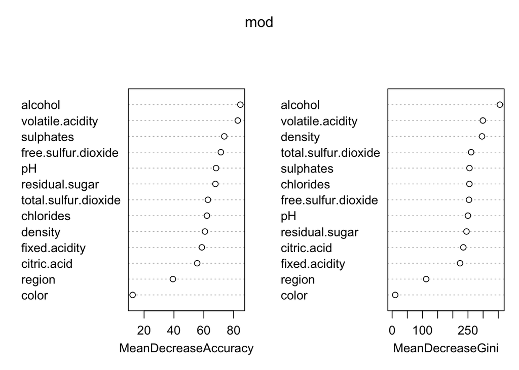

```r
# Variable importance plots
varImpPlot(mod)
```

When trying to assess influential wine features on quality, I modeled the quality scores and assessed what features impacted the model accuracy most. Based on the variable importance plots, alcohol appears to be the most influential characteristic. It is most important based on the MeanDecreaseGini and MeanDecreaseAccuracy. Furthermore, in the EDA, I had highlighted that it was the most correlated to quality rating.

## Targeted wine recommendation for Matt Crisp, response to question 4.

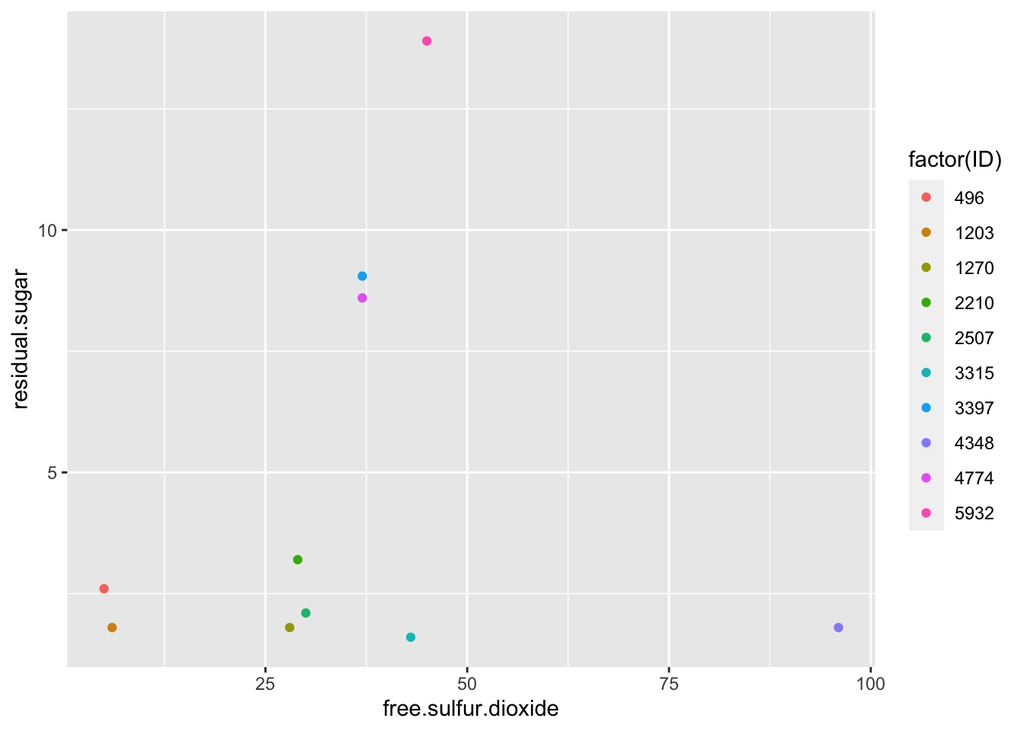

```r
party_wine_list <- c(unlist(party_wines_red[red_pos,'ID']),unlist(party_wines_white[white_pos,'ID']))
df_picked <- df %>% dplyr::filter(ID%in%party_wine_list)

# Current 10 recommended wines free.sulfur.dioxide and residual.sugar attributes
ggplot(data=df_picked, aes(free.sulfur.dioxide, residual.sugar, color=factor(ID))) + geom_point()
```

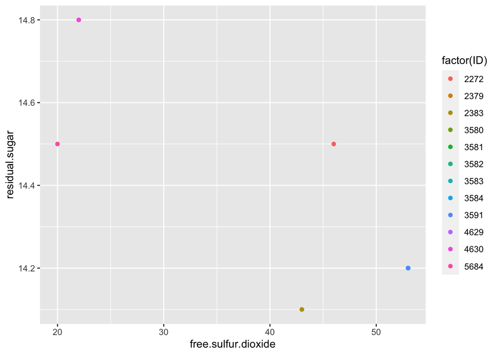

```r
# Plot of all wines with high residual.sugar and high quality
ggplot(data=df %>% dplyr::filter(quality >7 & residual.sugar >14),
       aes(free.sulfur.dioxide, residual.sugar, color=factor(ID))) + geom_point()
```

```r
party_wines_white %>% dplyr::filter(ID==4630) # ID = 4774 will be subbed out for ID = 4630 because 4774 was the original cluster 6 pick of the whites
```

```
## # A tibble: 1 x 17
##    ...1    ID color region fixed.acidity volatile.acidity citric.acid
##   <dbl> <dbl> <chr> <chr>          <dbl>            <dbl>       <dbl>
## 1  4630  4630 white B              0.218             1.51      -0.430
## # … with 10 more variables: residual.sugar <dbl>, chlorides <dbl>,
## #   free.sulfur.dioxide <dbl>, total.sulfur.dioxide <dbl>, density <dbl>,
## #   pH <dbl>, sulphates <dbl>, alcohol <dbl>, quality <dbl>, cluster <int>
```

```r
df %>% dplyr::filter(ID==4630)
```

```
## # A tibble: 1 x 16
##    ...1    ID color region fixed.acidity volatile.acidity citric.acid
##   <dbl> <dbl> <chr> <chr>          <dbl>            <dbl>       <dbl>
## 1  4630  4630 white B                7.1             0.47       0.290
## # … with 9 more variables: residual.sugar <dbl>, chlorides <dbl>,
## #   free.sulfur.dioxide <dbl>, total.sulfur.dioxide <dbl>, density <dbl>,
## #   pH <dbl>, sulphates <dbl>, alcohol <dbl>, quality <dbl>
```

```r
list_update <- c(party_wine_list, 4630)
list_update <- list_update[list_update!=4774]
rbind(party_wines_white, party_wines_red) %>%
  dplyr::filter(ID%in%list_update) %>%
  dplyr::select(color, ID, region)
```

```
## # A tibble: 10 x 3
##    color    ID region
##    <chr> <dbl> <chr>
##  1 white  2210 C
##  2 white  2507 C
##  3 white  3315 F
##  4 white  3397 B
##  5 white  4348 H
##  6 white  4630 B
##  7 white  5932 G
##  8 red     496 C
##  9 red    1203 C
## 10 red    1270 H
```

I would recommend that Matt Crisp have a glass of 4630.